# Data science capstone: milestone report.

Sergii Sorokolat

8/5/2018

## Summary

The goal of the capstone project is to build an app and a model for predicting a text based on a user’s input. The predictive model will be built using a large collection of text collected from various sources - news, blogs and twitter. This report showcases an exploratory analysis done on the data provided by SwiftKey and highligts key next steps for the project.

## Dataset

Due to a large size of original dataset, it was randomly sampled by 50k lines of text from each of document. These samples were then combined into a new dataset for further processing.

### 1. Define a function for reading from a file and sampling a small portion of the data

```r
readAndSampleFile <- function(fileName, sampleSize) {

    con <- file(fileName, open = "r", encoding = "UTF-8")
    lines <- readLines(con)

    idxs <- sample(1:length(lines), sampleSize)
    vals <- c()

     for (i in 1:length(lines)) {
        if (i %in% idxs) {
           vals <- append(vals, lines[i])
        }
     }
    close(con)
    vals
}
```

### 2. Read and sample from the original dataset

```r
setwd("~/Desktop/dscapstone/")

# bl <- readLines("final/en_US/en_US.blogs.txt")
# nw <- readLines("final/en_US/en_US.news.txt")
# tw <- readLines("final/en_US/en_US.twitter.txt")
#
# blWords <- sum(sapply(gregexpr("\\S+", bl), length))
# nwWords <- sum(sapply(gregexpr("\\S+", nw), length))
# twWords <- sum(sapply(gregexpr("\\S+", tw), length))
#
# b <- file.info("final/en_US/en_US.blogs.txt")$size / 1024 / 1024
# n <- file.info("final/en_US/en_US.news.txt")$size / 1024 / 1024
# t <- file.info("final/en_US/en_US.twitter.txt")$size / 1024 / 1024
#
#
# blLength <- length(bl)
# nwLength <- length(nw)
# twLength <- length(tw)
#
#
# d <- data.frame(file_name = c("en_US.blogs.txt","en_US.news.txt","en_US.twitter.txt"),
#         size = c(round(b, digits = 3),
#                      round(n,digits = 3),
#                      round(t, digits = 3)),
#         linesCount = c(blLength, nwLength, twLength),
#         wordsCount = c(blWords, nwWords, twWords))
#
# colnames(d) <- c("File", "File Size (Mb))", "Line Count", "Word Count")
# print(d)
```

```r
library(tidyverse)

set.seed(7152018)

## sample size
s <- 50000

samples <- c()
samples <- append(samples, readAndSampleFile(fileName = "final/en_US/en_US.blogs.txt", s))
samples <- append(samples, readAndSampleFile(fileName = "final/en_US/en_US.news.txt", s))
samples <- append(samples, readAndSampleFile(fileName = "final/en_US/en_US.twitter.txt", s))

## cleanup
gc()

saveRDS(samples, "samples150k.rds")
```

```r
samples <- readRDS("samples150k.rds")
summary(samples)
```

```
##    Length     Class      Mode
##    150000 character character
```

## 3. Profanity filtering

The list of word for filtering was obtained from https://github.com/LDNOOBW/List-of-Dirty-Naughty-Obscene-and-Otherwise-Bad-Words

```r
## profanity filtering
removeBadWords <- function(t, pattern) {
  for (i in 1:nrow(t)) {
    if (t[i, 2] == TRUE) {
      t[i,1] <- gsub(pattern, "*", t[i,1])
    }
  }
  t
}
```

```r
filter <- read.csv("sanityfilter_en.txt", header = FALSE, sep = "\n", as.is = TRUE)$V1

## to lowercase
t <- tbl_df(samples)
t <- mutate(t, value = str_to_lower(value))

## build the grep filter
f1 <- c()
for (i in 1:length(filter)) {
  ## \\<word\\>
  word <- paste("\\<", filter[i] ,"\\>", sep = "")
  f1 <- append(f1, word)
}
f <- paste(f1, sep = "", collapse = "|")
t$sanity_failed <- grepl(paste("(", f, ")", sep = ""), t$value)
# ##t$value <- gsub(paste("(", f, ")", sep = ""), "0", t$value, fixed = TRUE)

##t <-readRDS("samples150k-sanityfilter.rds")
# nrow(t[t$sanity_failed,])
#
saveRDS(t, "filtered.rds")
```

```r
samplesFiltered <- readRDS("filtered.rds")
t <- tbl_df(samplesFiltered)
nrow(t[t$sanity_failed,])

filter <- read.csv("sanityfilter_en.txt", header = FALSE, sep = "\n", as.is = TRUE)$V1
f1 <- c()
for (i in 1:length(filter)) {
  ## \\<word\\>
  word <- paste("\\<", filter[i] ,"\\>", sep = "")
  f1 <- append(f1, word)
}
f <- paste(f1, sep = "", collapse = "|")

t <- removeBadWords(t, paste("(", f, ")", sep = ""))
saveRDS(t, "preprocessed_needs_rm_spec_chars.rds")
```

### 4.Text preprocessing and tokenization

In order to perform text cleansing, I removed special characters, punctiation, numbers, extra whitespace and and made it lowercase. The next step is to build ngrams of one, two and three words.

```r
library(tidyverse)
library(tm)
library(RWeka)

t <- tbl_df(readRDS("preprocessed_needs_rm_spec_chars.rds"))
nrow(t[t$sanity_failed,])
```

```
## [1] 3485
```

```r
corp <- VCorpus(VectorSource(t$value))

corp <- tm_map(corp, content_transformer(function(x, pattern) gsub(pattern, " ", x)),  "“|”|–|…|‘|’")
corp <- tm_map(corp, content_transformer(removePunctuation))
corp <- tm_map(corp, content_transformer(removeNumbers))

corp <- tm_map(corp, stripWhitespace)

ngramtoken1 <- function(x) NGramTokenizer(x, Weka_control(min = 1, max = 1))
ngramtoken2 <- function(x) NGramTokenizer(x, Weka_control(min = 2, max = 2))
ngramtoken3 <- function(x) NGramTokenizer(x, Weka_control(min = 3, max = 3))

gc()
```

```
##             used  (Mb) gc trigger   (Mb) limit (Mb)  max used   (Mb)
## Ncells  10196590 544.6   22348741 1193.6         NA  22348741 1193.6
## Vcells 107783222 822.4  223534242 1705.5      16384 223534089 1705.5
```

```r
ngrammatr1 <- TermDocumentMatrix(corp, control = list(tokenize = ngramtoken1))
ngrammatr2 <- TermDocumentMatrix(corp, control = list(tokenize = ngramtoken2))
ngrammatr3 <- TermDocumentMatrix(corp, control = list(tokenize = ngramtoken3))


gc()
```

```
##             used   (Mb) gc trigger   (Mb) limit (Mb)  max used   (Mb)
## Ncells  14699579  785.1   22348741 1193.6         NA  22348741 1193.6
## Vcells 151690733 1157.4  223534242 1705.5      16384 223534089 1705.5
```

```r
preprocessed <- NULL
```

### Unigrams

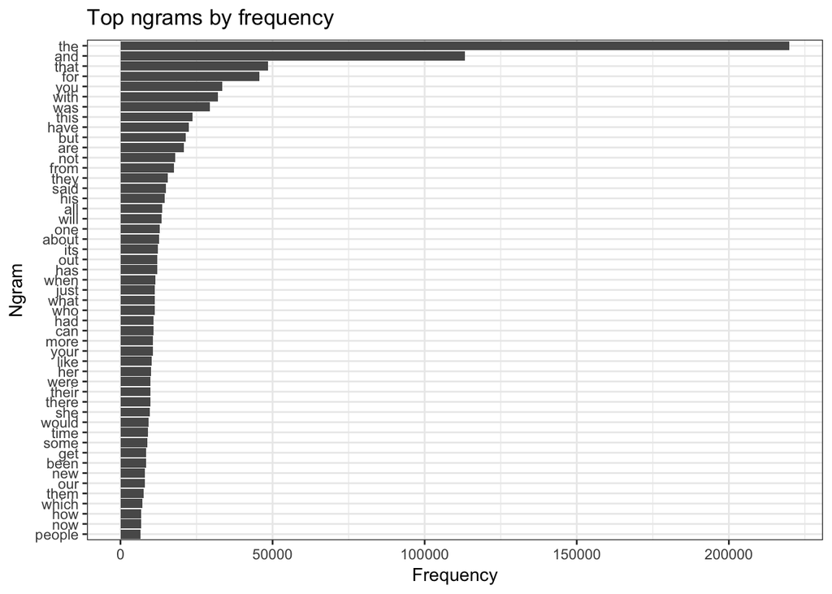

```r
library(ggplot2)
library(tm)
library(RWeka)
freqTerms <- findFreqTerms(ngrammatr1, lowfreq = 6500)
termFrequency <- rowSums(as.matrix(ngrammatr1[freqTerms,]))
termFrequency <- data.frame(ngrm=names(termFrequency), frequency=termFrequency)

preprocessed$termFrequency1 <- termFrequency

g <- ggplot(termFrequency, aes(x=reorder(ngrm, frequency), y=frequency)) +
    geom_bar(stat = "identity") + coord_flip() +
    xlab("Ngram") + ylab("Frequency") +
    labs(title = "Top ngrams by frequency") + theme_bw()

g
```

### Bigrams

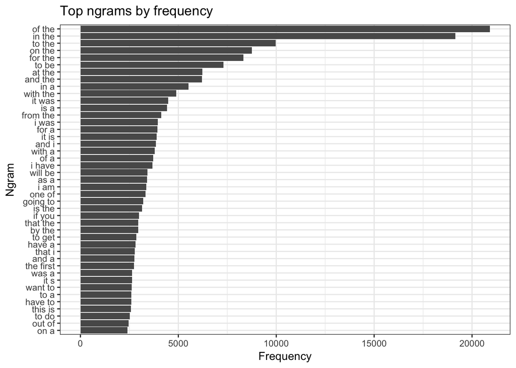

```r
library(tm)
library(RWeka)
freqTerms <- findFreqTerms(ngrammatr2, lowfreq = 2400)
termFrequency <- rowSums(as.matrix(ngrammatr2[freqTerms,]))
termFrequency <- data.frame(ngrm=names(termFrequency), frequency=termFrequency)

preprocessed$termFrequency2 <- termFrequency

g <- ggplot(termFrequency, aes(x=reorder(ngrm, frequency), y=frequency)) +
    geom_bar(stat = "identity") + coord_flip() +
    xlab("Ngram") + ylab("Frequency") +
    labs(title = "Top ngrams by frequency") + theme_bw()
g
```

### Trigrams

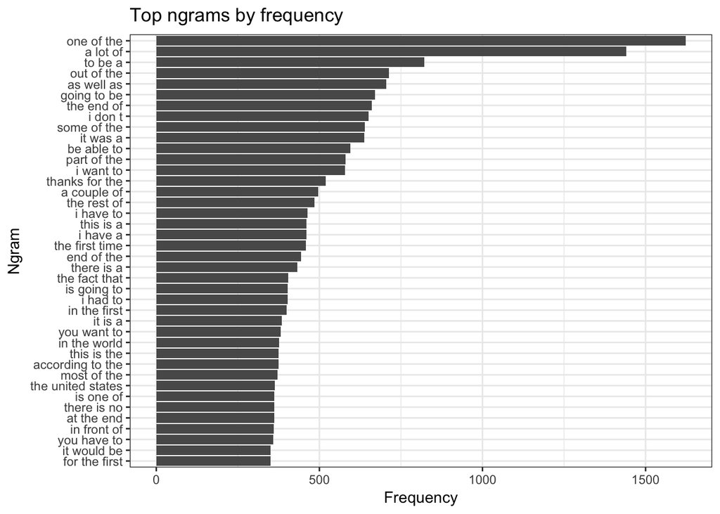

```r
library(tm)
library(RWeka)
freqTerms <- findFreqTerms(ngrammatr3, lowfreq = 350)
termFrequency <- rowSums(as.matrix(ngrammatr3[freqTerms,]))
termFrequency <- data.frame(ngrm=names(termFrequency), frequency=termFrequency)

preprocessed$termFrequency3 <- termFrequency

g <- ggplot(termFrequency, aes(x=reorder(ngrm, frequency), y=frequency)) +
    geom_bar(stat = "identity") +  coord_flip() +
    xlab("Ngram") + ylab("Frequency") +
    labs(title = "Top ngrams by frequency") + theme_bw()

g
```

### 5. Plans

1. Build a model to handle unseen n-grams - in some cases people will want to type a combination of words that does not appear in the corpora. Build a model to handle cases where a particular n-gram isn’t observed.
2. Build predictive model(s) using the tokens from n-grams.
3. Develop Shiny app to make word predictions based on user’s input.

## Save preprocessed data

```r
preprocessed$corpus <- corp
preprocessed$ngrammatr1 <- ngrammatr1
preprocessed$ngrammatr2 <- ngrammatr2
preprocessed$ngrammatr3 <- ngrammatr3

saveRDS(preprocessed, "preprocessed.rds")
```